# Skalowanie wielowymiarowe

Skalowanie wielowymiarowe to metoda pozwalająca zwizualizować obiekty n-wymiarowe w przestrzeni m-wymiarowej (m<n).

## **Klasyczne skalowanie wielowymiarowe**

- Ideą klasycznego skalowania wielowymiarowego jest zmniejszenie wymiaru danych przy jak najmniejszym zniekształceniu prawdziwych odległości.
- Opiera się na odległościach euklidesowych pomiędzy obiektami.
- Wykorzystywane jest w przypadku zmiennych metrycznych.
- Metoda jednokrokowa.
- Metoda liniowa.
- Do oceny jakości rzutowania może posłużyć np. współczynnik STRESS:

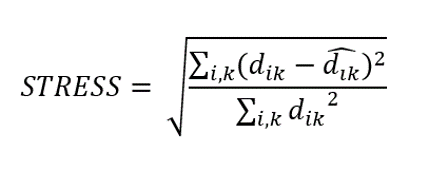

  gdzie:
  - $i$ - indeks obiektu
  - $k$ - indeks obiektu
  - $d_{ik}$ - odległość pomiędzy i-tym i k-tym obiektem (wyznaczona na podstwie początkowych danych)
  - $\hat{d}_{ik}$ - odległość pomiędzy i-tym i k-tym obiektem (wyznaczona na podstwie wartości uzyskanych po zastosowaniu skalowania wielowymiarowego)

Funkcja `cmdscale()` z biblioteki `stats`:

`cmdscale(d, k, ...)`

gdzie:

- d - macierz odległości/macierz niepodobieństw
- k - maksymalny wymiar przestrzeni, w której mają być reprezentowane dane

Dokumentacja: https://www.rdocumentation.org/packages/stats/versions/3.6.2/topics/cmdscale

## **Metoda skalowania Sammona**

- W metodzie tej wykorzystywane są odległości metryczne (często odległość euklidesowa).
- Kładzie większy nacisk na dokładne odwzorowanie małych odległości (odpowiedni dobór wag).
- Metoda nieliniowa.
- Metoda iteracyjna.
- Rozwiązuje problem optymalizacyjny, w którym minimalizowany jest błąd:

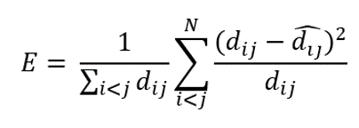

Funkcja `sammon()` z biblioteki `MASS`:

`sammon(d, k, ...)`

gdzie:

- d - macierz odległości/macierz niepodobieństw
- k - maksymalny wymiar przestrzeni, w której mają być reprezentowane dane

Dokumentacja: https://www.rdocumentation.org/packages/MASS/versions/7.3-53/topics/sammon

## **Niemetryczne skalowanie wielowymiarowe**

- Ideą niemetrycznego skalowania wielowymiarowego jest znalezienie reprezentacji, która odwzorowuje kolejność odległości pomiędzy obiektami a nie odległość pomiędzy nimi (ważny jest porządek rangowy, a nie odległość między obiektami).
- Wykorzystywane w przypadku zmiennych mierzonych na skali porządkowej.
- Metoda iteracyjna.

Funkcja `isoMDS()` z biblioteki `MASS`:

`isoMDS(d, k, ...)`

gdzie:

- d - macierz odległości/macierz niepodobieństw
- k - maksymalny wymiar przestrzeni, w której mają być reprezentowane dane

Dokumentacja: https://www.rdocumentation.org/packages/MASS/versions/7.3-58.1/topics/isoMDS

### Dodatkowe materiały

- Funkcje przydatne do wizualizacji wyników:
  - Wykresy 2-wymiarowe: `plot(x, y, ...)`, `text(x, y, labels, pos, ...)` z biblioteki `graphics`.
  - Wykresy 3-wymiarowe: `plot3d(x, y, z, ...)`, `text3d(x, y, z, texts, ...)` z biblioteki `rgl`.
- Opis metod wraz z przykładami:  
  https://pages.mtu.edu/~shanem/psy5220/daily/Day16/MDS.html#sammons-non-linear-scaling-method
- Skalowanie metryczne w R:  
  http://www.gastonsanchez.com/visually-enforced/how-to/2013/01/23/MDS-in-R/
- Skalowanie wielowymiarowe w R:  
  http://www.sthda.com/english/articles/31-principal-component-methods-in-r-practical-guide/122-multidimensional-scaling-essentials-algorithms-and-r-code/#visualizing-a-correlation-matrix-using-multidimensional-scaling